*Projekt zaliczeniowy 1*

Ada Hryniewicka

Wszędzie, gdzie nie podano inaczej w treści polecenia, przyjmuję poziom istotności równy 0.05.

**1. Wczytywanie danych**

```r
dane <- read.table("/Users/ads/Desktop/SAD/projekt1/people.tab.csv",header = TRUE)
colnames(dane)
```

```
## [1] "wiek"          "waga"          "wzrost"        "plec"
## [5] "stan_cywilny"  "liczba_dzieci" "budynek"       "wydatki"
## [9] "oszczednosci"
```

```r
head(dane)
```

```
##   wiek waga wzrost plec stan_cywilny liczba_dzieci      budynek wydatki
## 1   25 61.7 121.12 <NA>        FALSE             2         loft 1662.91
## 2   37 63.9 145.00    M         TRUE             6 wielka_plyta 4041.86
## 3   41 50.2 145.03    K         TRUE             2   apartament 3853.45
## 4   43 72.4 179.90    M        FALSE             1 wielka_plyta 2398.88
## 5   26 78.4 163.91    M        FALSE             1   apartament 2344.45
## 6   49 59.4 151.86    K         TRUE             2         loft 1967.87
##   oszczednosci
## 1        23.44
## 2        96.84
## 3       312.68
## 4       447.43
## 5       -78.23
## 6      1241.98
```

```r
sum(is.na(dane))
```

```
## [1] 38
```

```r
df = subset(dane, select = -c(4,5,7) )
cor(x=df, y = NULL, use = "everything",
    method = c("pearson", "kendall", "spearman"))
```

```
##                       wiek        waga      wzrost liczba_dzieci    wydatki
## wiek           1.000000000 -0.06918028 -0.04130021   0.006910684  0.1788953
## waga          -0.069180283  1.00000000  0.69825994  -0.040597107 -0.1150781
## wzrost        -0.041300207  0.69825994  1.00000000  -0.039969222 -0.1835381
## liczba_dzieci  0.006910684 -0.04059711 -0.03996922   1.000000000  0.6343567
## wydatki        0.178895316 -0.11507806 -0.18353806   0.634356663  1.0000000
## oszczednosci   0.892785726  0.01884639  0.03803426  -0.046747778 -0.1136105
##               oszczednosci
## wiek            0.89278573
## waga            0.01884639
## wzrost          0.03803426
## liczba_dzieci  -0.04674778
## wydatki        -0.11361047
## oszczednosci    1.00000000
```

**2. Wykresy podsumowujące dane**

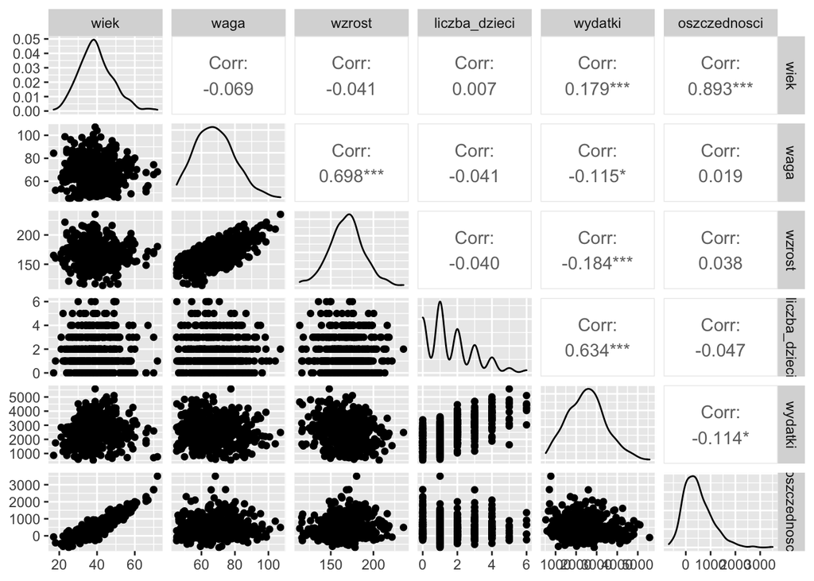

```r
library(ggplot2)
library(GGally)
ggpairs(dane, columns=c(1, 2, 3, 6, 8, 9))
```

```r
# ggpairs(dane, aes(col=plec), columns=c(1, 2, 3, 6, 8, 9))
# ggpairs(dane, aes(col=stan_cywilny), columns=c(1, 2, 3, 6, 8, 9))
# ggpairs(dane, aes(col=budynek), columns=c(1, 2, 3, 6, 8, 9))
```

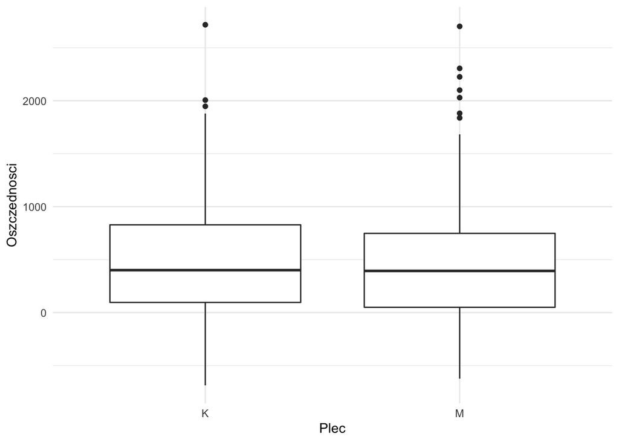

```r
dane=na.omit(dane)
ggplot(data = data.frame('Oszczednosci' = dane$oszczednosci, 'Plec' = dane$plec)) + geom_boxplot(aes(x = Plec, y = Oszczednosci)) + theme_minimal()
```

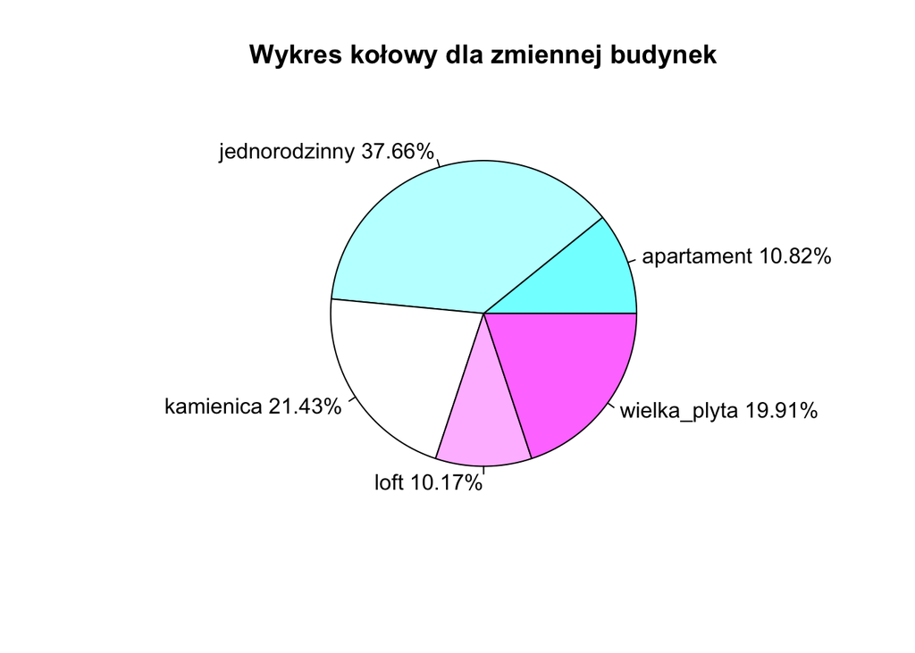

```r
library(plyr)
budynki <- count(dane, 'budynek')
budynki_count <- budynki$freq

pie_labels <- paste0(round(100 * budynki_count/sum(budynki_count), 2), "%")

pie(budynki_count, labels = paste0(budynki$budynek,' ' ,pie_labels), col=cm.colors(length(budynki_count)), main='Wykres kołowy dla zmiennej budynek')
```

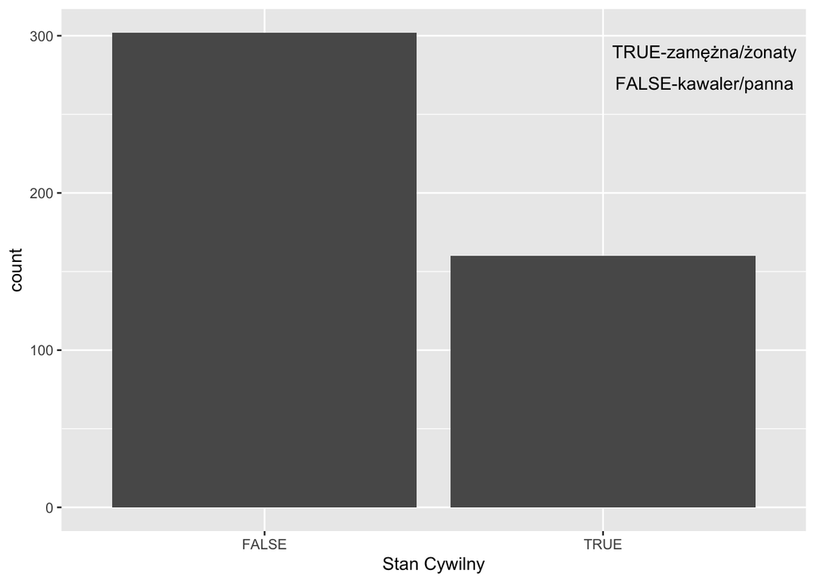

```r
ggplot(data.frame(dane$stan_cywilny), aes(x=dane$stan_cywilny)) +
  geom_bar() + xlab('Stan Cywilny') +ylab('count') + annotate("text", x=2.3, y=290, label= "TRUE-zamężna/żonaty") + annotate("text", x=2.3, y=270, label= "FALSE-kawaler/panna")
```

**3. P-wartości dla hipotez o wartości średniej m=170 i mediane me=165(cm) dla zmiennej wzrost.**

Pierwszy krok to obejrzenie rozkładu danych na histogramie i sprawdzenie normalności rozkładu testem Shapiro- Wilka,

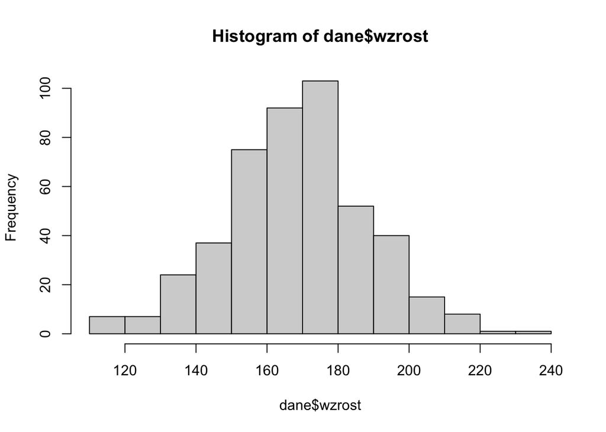

```r
hist(dane$wzrost)
```

```r
shapiro.test(dane$wzrost)$p.value
```

```
## [1] 0.4201036
```

Nie ma podstaw do odrzucenia hipotezy, że rozkład jest normalny p.value=0.42, dla testu S-W. Do przetestowania hipotezy o wartości średniej można wykorzystać test t-studenta.

```r
t.test(x=dane$wzrost,mu=170, alternative='less')
```

```
##
##  One Sample t-test
##
## data:  dane$wzrost
## t = -1.7876, df = 461, p-value = 0.03725
## alternative hypothesis: true mean is less than 170
## 95 percent confidence interval:
##      -Inf 169.8717
## sample estimates:
## mean of x
##   168.355
```

P.value dla średniej wyniosło 0.03725, są podstawy do odrzucenia hipotezy zerowej jeśli przyjmemy α = 0.05. Dla sprawdzenie mediany wykorzystano nieparametryczny test Wilcoxona.

```r
wilcox.test(dane$wzrost, mu = 165, alternative = "less")
```

```
##
##  Wilcoxon signed rank test with continuity correction
##
## data:  dane$wzrost
## V = 64120, p-value = 0.9999
## alternative hypothesis: true location is less than 165
```

P.value dla podanej mediany wyniosło 0.999, nie ma podstaw do odrzucenia hipotezy zerowej.

**4. Dwustronne przedziały ufności na poziomie 0.99 dla zmiennej wiek.**

Korzystałam z wzorów dla nieznanej średniej i odchyleniu standardowym przy założeniu, że próba ma rozkład normalny (sprawdzenie histogramu oraz q-q plota). Wykorzystałam rozkład t-studenta dla średniej i rozkład chi-kwadrat dla odchylenia.

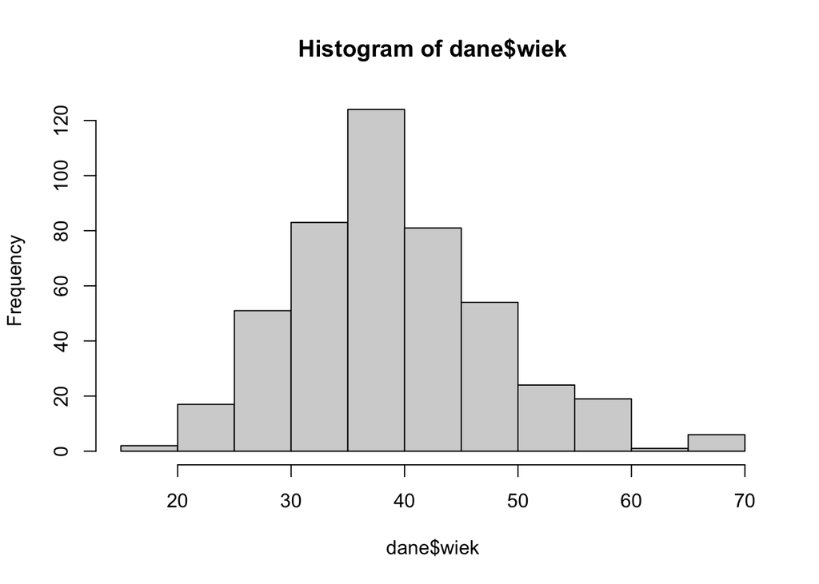

```r
hist(dane$wiek)
```

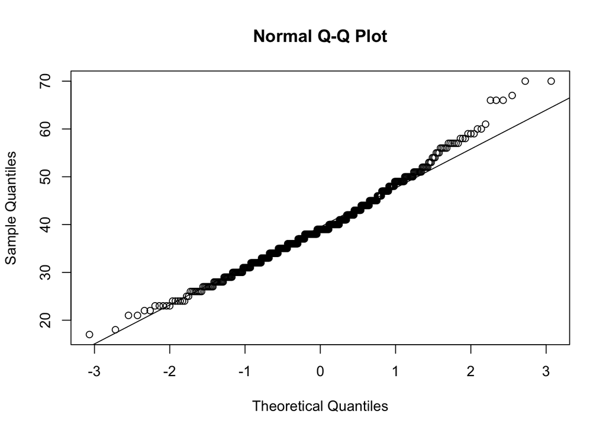

```r
qqnorm(dane$wiek)
qqline(dane$wiek)
```

```r
srednia<-mean(dane$wiek)
s<- qt(0.01,length(dane$wiek)-1)*sd(dane$wiek)/(sqrt(length(dane$wiek)-1))
srednia+s
```

```
## [1] 38.52821
```

```r
srednia-s
```

```
## [1] 40.46746
```

```r
chi1<-qchisq(1-0.005,length(dane$wiek)-1)
chi2<-qchisq(0.005,length(dane$wiek)-1)
sqrt(length(dane$wiek)*var(dane$wiek)/chi1)
```

```
## [1] 8.226242
```

```r
sqrt(length(dane$wiek)*var(dane$wiek)/chi2)
```

```
## [1] 9.74962
```

Przedział ufności dla odchylenia standardowego to (8.23,9.75).

Dla sprawdzenia kwantyli wykorzystałam bibliotekę quantileCI, która opisana jest na załączonej stronie o kwantylach. Założenia są spełnione, ponieważ jest ona odporna na różnego typu dystrybucje i rozmiary próby. Dodatkowo została opisana jako jedna z najszybszych metod i polecana przez autorów do używania w praktyce.

Dla kwantyli:

```r
library(quantileCI)
quantile_confint_nyblom(x=dane$wiek, p=0.25, conf.level=0.99,interpolate=TRUE)
```

```
## [1] 32 35
```

```r
quantile_confint_nyblom(x=dane$wiek, p=0.5, conf.level=0.99,interpolate=TRUE)
```

```
## [1] 38 40
```

```r
quantile_confint_nyblom(x=dane$wiek, p=0.75, conf.level=0.99,interpolate=TRUE)
```

```
## [1] 43 47
```

Kwantyl 1/4: (32,35) Kwantyl 2/4(mediana): (38,40) Kwantyl 3/4: (43,47)

**5. Testowanie hipotez na poziomie istotności 0.1**

1. H0: Średnie wartości wydatków pomiędzy osobami zamężnymi/żonatymi a pannami/kawalerami są równe. H1:Średnie wartości wydatków pomiędzy osobami zamężnymi/żonatymi a pannami/kawalerami są różne.

Sprawdzenie z jakim rozkładem mam doczynienia. Dla obu zestawu danych- zamężne/żonaci i panny/kawalerowie.

```r
z<-dane$wydatki[dane$stan_cywilny=='TRUE']
w<-dane$wydatki[dane$stan_cywilny=='FALSE']

shapiro.test(z)$p.value
```

```
## [1] 0.6256072
```

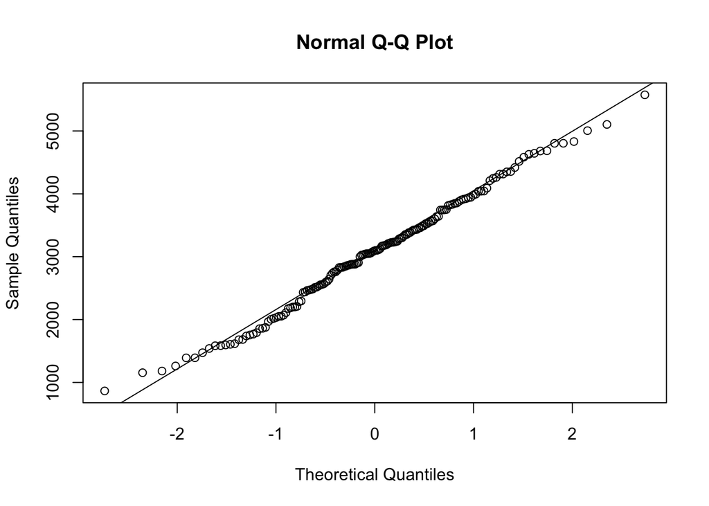

```r
qqnorm(z)
qqline(z)
```

```r
shapiro.test(w)$p.value
```

```
## [1] 0.05510601
```

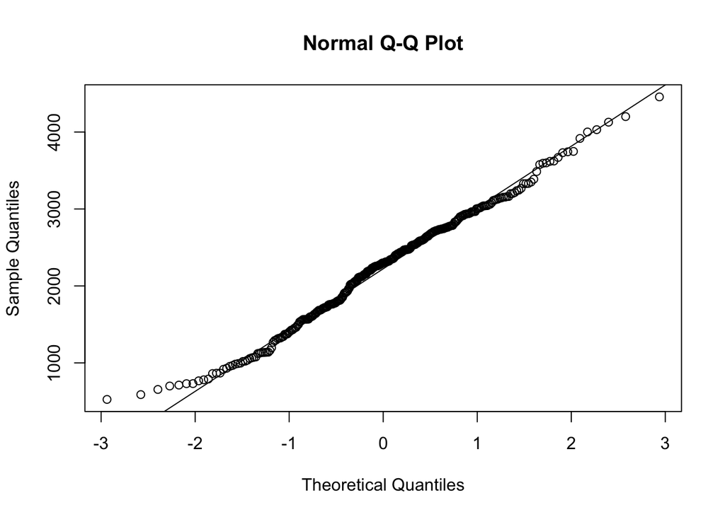

```r
qqnorm(w)
qqline(w)
```

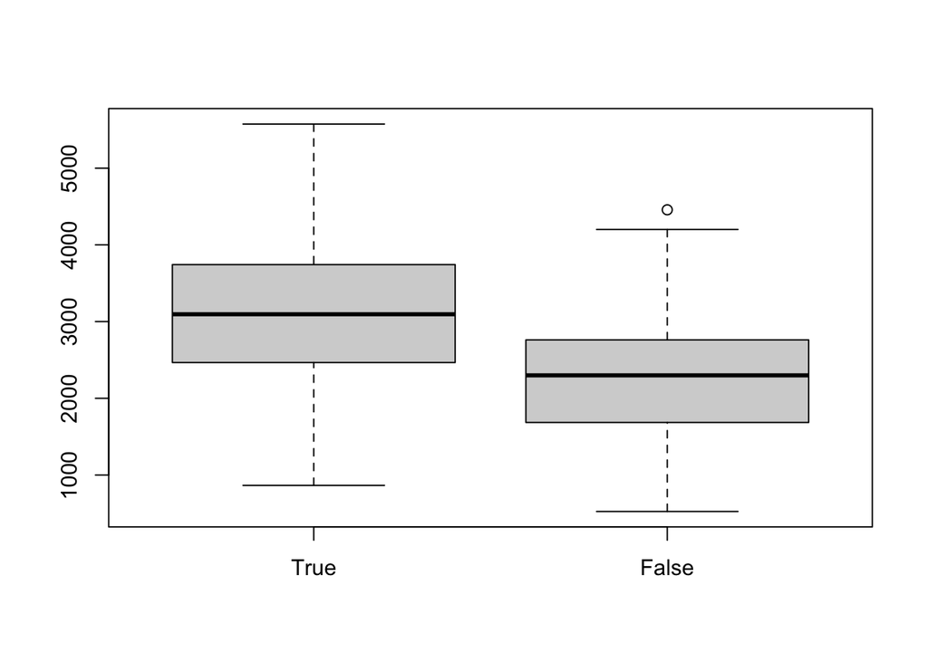

```r
boxplot(z, w, names=c("True","False"))
```

Dla sprawdzenia czy wariancje są równe wykonuje test Fishera.

```r
var.test(z, w, alternative = "two.sided")
```

```
##
##  F test to compare two variances
##
## data:  z and w
## F = 1.4742, num df = 159, denom df = 301, p-value = 0.00425
## alternative hypothesis: true ratio of variances is not equal to 1
## 95 percent confidence interval:
##  1.129076 1.947377
## sample estimates:
## ratio of variances
##           1.474232
```

Z testu Fishera widać, że nie można założyć, że wariancje są równe. Z boxplota Widać różnicę w średniej. Przeprowadzam test Welcha.

```r
t.test(w, z)
```

```
##
##  Welch Two Sample t-test
##
## data:  w and z
## t = -9.5321, df = 275.05, p-value < 2.2e-16
## alternative hypothesis: true difference in means is not equal to 0
## 95 percent confidence interval:
##  -993.5492 -653.4092
## sample estimates:
## mean of x mean of y
##  2240.328  3063.807
```

Wniosek: Jest podstawa do odrzucenia hipotezy zerowej. Średnie wydatki nie są równe.

2. H0: Wydatki i oszczędności są niezależne H1: Wydatki i oszczędności są zależne

```r
wyd<-dane$wydatki
osz<-dane$oszczednosci

shapiro.test(wyd)$p.value
```

```
## [1] 0.01201285
```

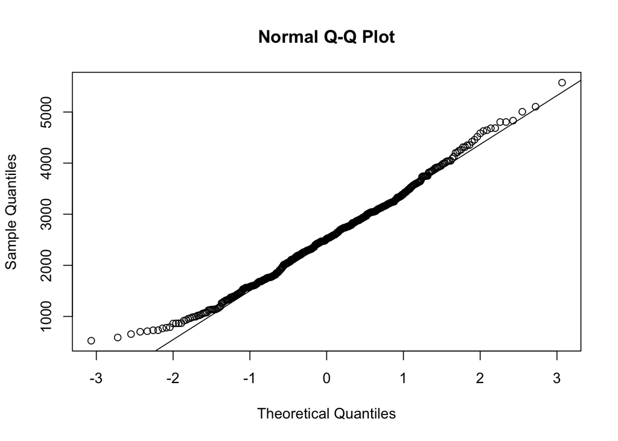

```r
qqnorm(wyd)
qqline(wyd)
```

```r
shapiro.test(osz)$p.value
```

```
## [1] 1.927469e-10
```

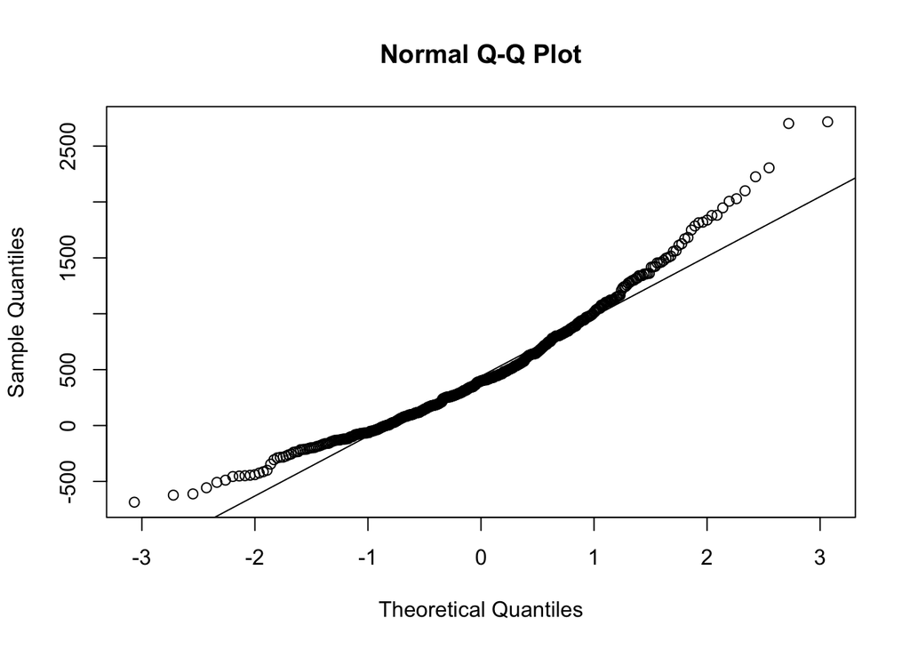

```r
qqnorm(osz)
qqline(osz)
```

W tym przypadku nie zakładamy, że dane mają rozkład normalny. W takim wypadku wybieram test Spearmana, który dobrze sprawdza się w przypadku rozkładu innego niż normalny i jest odporny na przypadki odstające.

```r
cor.test(wyd, osz,  method = "spearman")
```

```
##
##  Spearman's rank correlation rho
##
## data:  wyd and osz
## S = 17308626, p-value = 0.2542
## alternative hypothesis: true rho is not equal to 0
## sample estimates:
##         rho
## -0.05314932
```

Nie ma podstaw do odrzucenia hipotezy zerowej. Wydatki i oszczędności nie wykazują zależności.

3. H0: Płeć i stan cywilny są niezależne. H1: Płeć i stan cywilny są zależne.

```r
p<-dane$plec
s<-dane$stan_cywilny
#tabela kotyngencji
table(p, s)
```

```
##    s
## p   FALSE TRUE
##   K   148   91
##   M   154   69
```

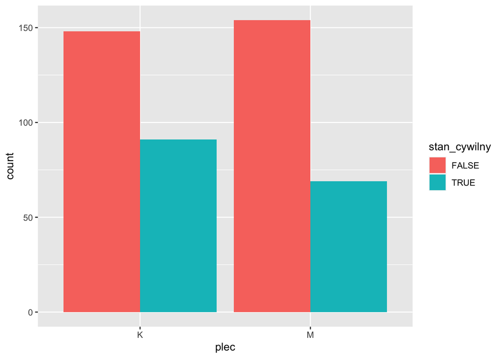

```r
#zwizualizowanie sobie danych w postaci barplotu
ggplot(dane) +
  aes(x = plec, fill = stan_cywilny) +
  geom_bar(position = "dodge")
```

Do testowania zmiennych jakościowych wykorzytsam test niezależności chi kwadrat. Założenie o liczebności próby jest spełnione, tak samo z niezależnością grup.

```r
chisq.test(table(p,s),correct = FALSE)
```

```
##
##  Pearson's Chi-squared test
##
## data:  table(p, s)
## X-squared = 2.5932, df = 1, p-value = 0.1073
```

```r
#alternatywna funkcja
#summary(table(p,s))
```

Nie ma podstaw do odrzucenia hipotezy zerowej. Płeć i stan cywilny są niezależne.

4. H0: zmienna waga ma rozkład wykładniczy z parametrem H1: zmienna waga nie ma rozkładu wykładniczego z parametrem 5.

Do sprawdzenia tej hipotezy wykorzystałam test Kolmogorova-Smirnova.

```r
ks.test(dane$waga, 'pexp',5)
```

```
##
##  One-sample Kolmogorov-Smirnov test
##
## data:  dane$waga
## D = 1, p-value < 2.2e-16
## alternative hypothesis: two-sided
```

Są podstawy do orzucenia hipotezy zerowej. Nie można stwierdzić, aby zmienna waga miała rozkład wykładniczy o parametrze 5.

**6. Model regresji liniowej**

Dane jakościowe należy zmienić na typ factor.

```r
dane$plec <- as.factor(dane$plec)
dane$budynek <- as.factor(dane$budynek)
dane$stan_cywilny <- as.factor(dane$stan_cywilny)
model <- lm(oszczednosci ~ ., dane)
summary(model)
```

```
##
## Call:
## lm(formula = oszczednosci ~ ., data = dane)
##
## Residuals:
##     Min      1Q  Median      3Q     Max
## -307.64  -60.13   -1.69   58.06  462.98
##
## Coefficients:
##                        Estimate Std. Error t value Pr(>|t|)
## (Intercept)          -873.59106   58.76098 -14.867  < 2e-16 ***
## wiek                   63.94258    0.56712 112.750  < 2e-16 ***
## waga                    3.94409    0.56935   6.927 1.49e-11 ***
## wzrost                 -2.38464    0.35204  -6.774 3.94e-11 ***
## plecM                   1.38069    9.63179   0.143    0.886
## stan_cywilnyTRUE       -4.61252   12.91187  -0.357    0.721
## liczba_dzieci         151.60355    6.15687  24.623  < 2e-16 ***
## budynekjednorodzinny -182.07031   16.43991 -11.075  < 2e-16 ***
## budynekkamienica     -305.63144   17.89020 -17.084  < 2e-16 ***
## budynekloft          -338.47001   25.14078 -13.463  < 2e-16 ***
## budynekwielka_plyta  -564.26015   20.59225 -27.402  < 2e-16 ***
## wydatki                -0.39593    0.01057 -37.455  < 2e-16 ***
## ---
## Signif. codes:  0 '***' 0.001 '**' 0.01 '*' 0.05 '.' 0.1 ' ' 1
##
## Residual standard error: 102 on 450 degrees of freedom
## Multiple R-squared:  0.9673, Adjusted R-squared:  0.9665
## F-statistic:  1209 on 11 and 450 DF,  p-value: < 2.2e-16
```

p.values dla każdego parametru zaprezentowane są w kolumnie Pr(>|t|). Oszacowania współczynników są wypisane w kolumnie Estimate. R^2=0.9673

```r
#Obliczanie RSS
with(summary(model), df[2] * sigma^2)
```

```
## [1] 4681334
```

```r
#alternatywnie
#library(qpcR)
#RSS(model)
```

RSS=4681334

Dla upewnienia się konstruuję przedziały ufności i sprawdzam, czy należy do nich 0.

```r
confint(model)
```

```
##                            2.5 %       97.5 %
## (Intercept)          -989.071057 -758.1110708
## wiek                   62.828047   65.0571085
## waga                    2.825166    5.0630144
## wzrost                 -3.076484   -1.6927966
## plecM                 -17.548186   20.3095560
## stan_cywilnyTRUE      -29.987562   20.7625166
## liczba_dzieci         139.503762  163.7033356
## budynekjednorodzinny -214.378846 -149.7617725
## budynekkamienica     -340.790148 -270.4727413
## budynekloft          -387.877909 -289.0621031
## budynekwielka_plyta  -604.729067 -523.7912246
## wydatki                -0.416700   -0.3751522
```

Stan cywilny i płeć w swoich przedziałach ufności zawierają 0. Możemy zakładać, że mogą być nieistotne statystycznie. Zdecydowałam, że zmienną, którą odrzucam jest płeć i przystępuje do tworzenia nowego modelu bez niej.

```r
model2 <- lm(oszczednosci ~ . -plec , dane)
summary(model2)
```

```
##
## Call:
## lm(formula = oszczednosci ~ . - plec, data = dane)
##
## Residuals:
##     Min      1Q  Median      3Q     Max
## -306.83  -60.62   -1.79   58.67  463.67
##
## Coefficients:
##                        Estimate Std. Error t value Pr(>|t|)
## (Intercept)          -872.88762   58.49209 -14.923  < 2e-16 ***
## wiek                   63.94122    0.56642 112.886  < 2e-16 ***
## waga                    3.94887    0.56776   6.955 1.24e-11 ***
## wzrost                 -2.38524    0.35163  -6.783 3.70e-11 ***
## stan_cywilnyTRUE       -4.83341   12.80566  -0.377    0.706
## liczba_dzieci         151.69318    6.11838  24.793  < 2e-16 ***
## budynekjednorodzinny -182.14265   16.41431 -11.097  < 2e-16 ***
## budynekkamienica     -305.65338   17.87011 -17.104  < 2e-16 ***
## budynekloft          -338.69765   25.06331 -13.514  < 2e-16 ***
## budynekwielka_plyta  -564.40762   20.54419 -27.473  < 2e-16 ***
## wydatki                -0.39600    0.01055 -37.548  < 2e-16 ***
## ---
## Signif. codes:  0 '***' 0.001 '**' 0.01 '*' 0.05 '.' 0.1 ' ' 1
##
## Residual standard error: 101.9 on 451 degrees of freedom
## Multiple R-squared:  0.9673, Adjusted R-squared:  0.9665
## F-statistic:  1332 on 10 and 451 DF,  p-value: < 2.2e-16
```

```r
R1<-0.9673
R2<-0.9673
roznica_R<-R1-R2
RSS1<-4681334
RSS2<-with(summary(model2), df[2] * sigma^2)
roznica_RSS<-RSS2-RSS1
roznica_R
```

```
## [1] 0
```

```r
roznica_RSS
```

```
## [1] 213.6199
```

Różnica pomiędzy wartościami R^2, przed usunięciem zmiennej płeć i po wynosi 0. Natomiast RSS, zwiększyło się o 213.62.

Sprawdzenie czy jest spełnione założenie o formie funkcyjnej:

```r
library(lmtest)
resettest(model2)
```

```
##
##  RESET test
##
## data:  model2
## RESET = 2.84, df1 = 2, df2 = 449, p-value = 0.05948
```

P.value > 0.05, więc nie ma podstaw do odrzucenia hipotezy zerowej. Jednak trzeba mieć na uwadze, że wartość p.value jest bliska progu 0.05.

Wykresy diagnostyczne:

1. Wykres reszt vs wartości dopasowanych, aby sprawdzić, czy występuje heteroskedastyczność.

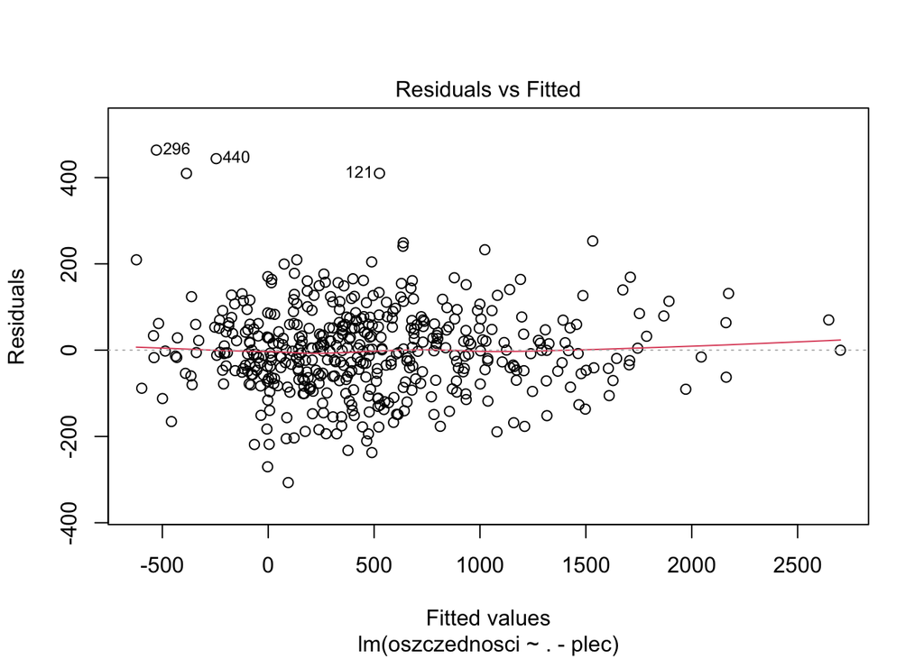

```r
plot(model2, which = 1)
```

Linia nie ma znaczących odchyleń od prostej- można stwierdzić, że występuje homoskedastyczność.

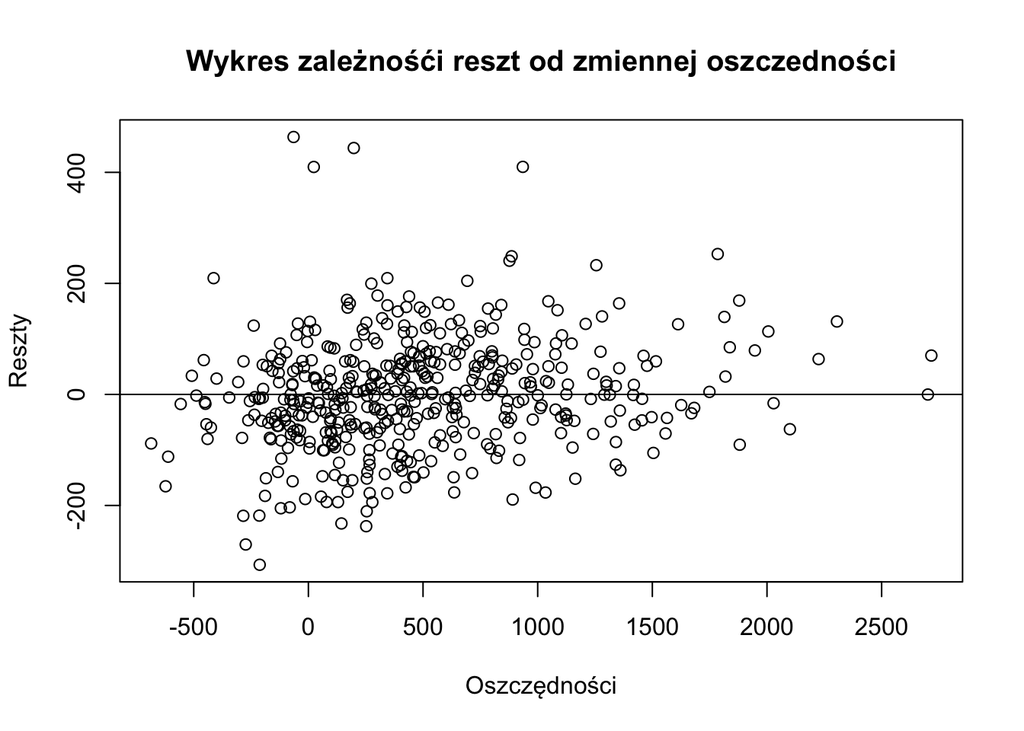

```r
oszcz.res = resid(model2)
 plot(dane$oszczednosci, oszcz.res,
     ylab="Reszty", xlab="Oszczędności",
     main="Wykres zależnośći reszt od zmiennej oszczedności")
abline(0, 0)
```

Wykres wygląda na poprawny, wariancja nie rośnie, nie występują trendy.

2. Wykres reszt studentyzowanych

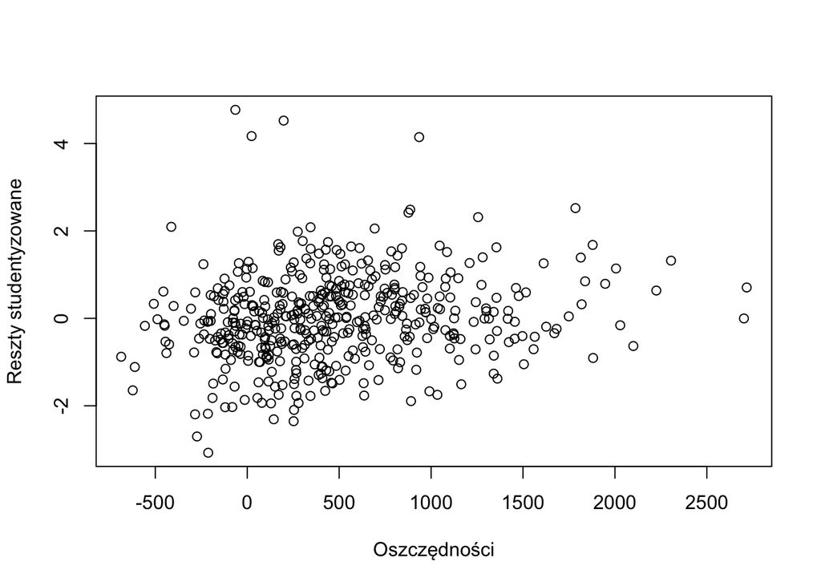

```r
library(MASS)
mres <- studres(model2)
plot(dane$oszczednosci, mres,  ylab='Reszty studentyzowane', xlab='Oszczędności')
```

Wnioski takie same jak w wykresie powyżej.

3. Wykres dźwigni

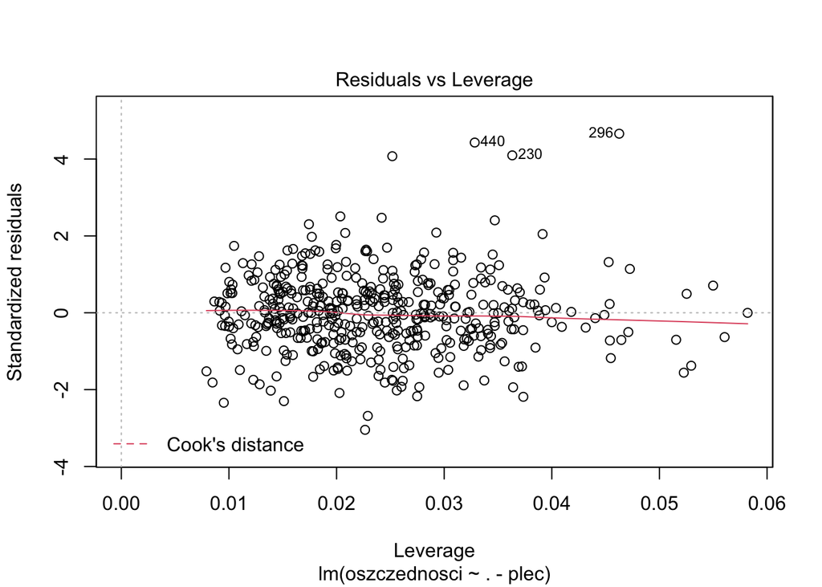

```r
plot(model2, which=5)
```

Nie ma niepokojących obserwacji w skrajnym górnym i dolnym prawym rogu, które miałyby wysokie wartości dźwigni i wysoką wartość reszt.